# Analyse - Freie Berufe & Rente

# Freie Berufe

## Fragestellungen

- Welcher Inflationsindex passt am besten zu den Daten?
- Was fällt bei den verschiedenen Indizes auf?
- Wie können die Unterschiede zwischen den Indizes erklärt werden?

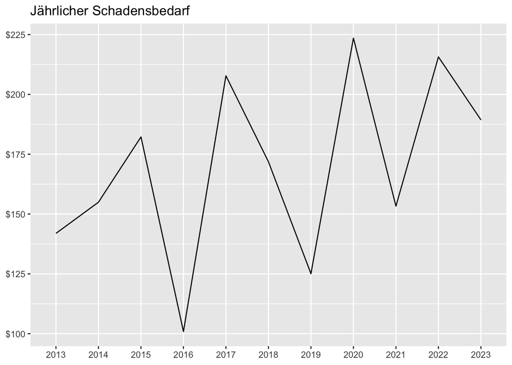

```r
d |>
  filter(name == "Schadensbedarf") |>
  ggplot(aes(Jahr, `Jährliche Inflation`, group = name)) +
  geom_line() +
  scale_y_continuous(labels = scales::dollar_format()) +
  labs(
    title = "Jährlicher Schadensbedarf"
    , x = NULL, y = NULL
  ) +
  theme(legend.position = "none")
```

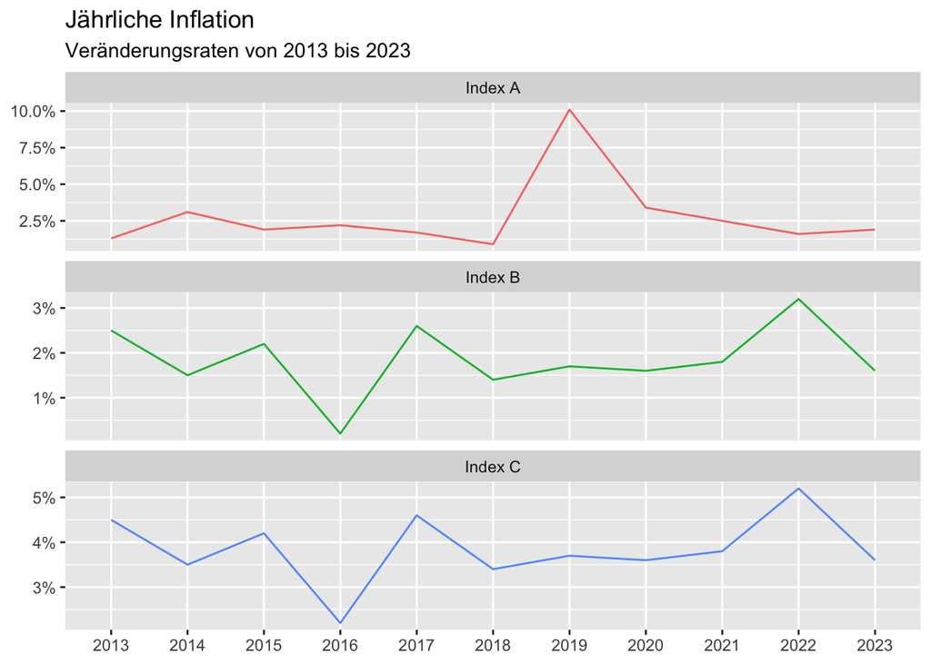

```r
d |>
  filter(name != "Schadensbedarf") |>
  ggplot(aes(Jahr, `Jährliche Inflation`, colour = name, group = name)) +
  geom_line() +
  facet_wrap(vars(name), scales = "free_y", ncol = 1) +
  scale_y_continuous(labels = scales::percent_format()) +
  labs(
    title = "Jährliche Inflation"
    , subtitle = "Veränderungsraten von 2013 bis 2023"
    , x = NULL, y = NULL
  ) +
  theme(legend.position = "none")
```

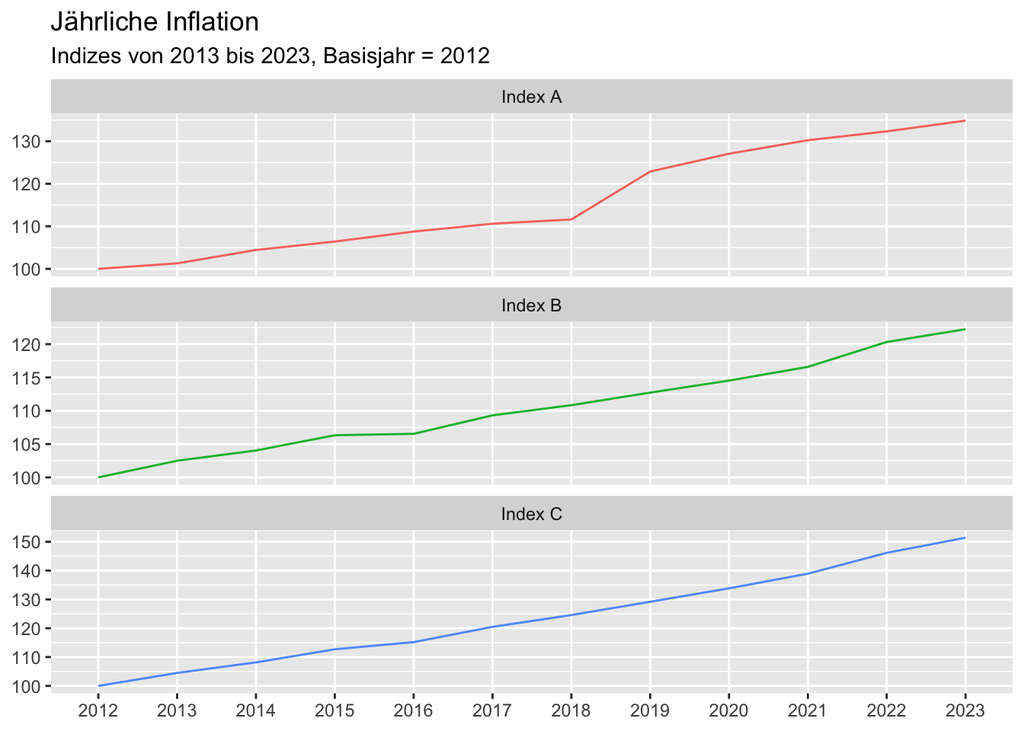

```r
d_raw |>
  transmute(
    Jahr = factor(Anfalljahr)
    , Schadensbedarf = `Historischer Schadenbedarf`
    , `Index A` = `Jährliche Inflation Index A` +1
    , `Index B` = `Jährliche Inflation Index B` +1
    , `Index C` = `Jährliche Inflation Index C` +1
  ) -> x

tribble(
  ~Jahr, ~Schadensbedarf, ~`Index A`, ~`Index B`, ~`Index C`
  , 2012, 0, 100, 100, 100
) |> mutate(Jahr = factor(Jahr)) |>
  bind_rows(x) |>
  transmute(
    Jahr
    , `Index A` = accumulate(`Index A`, `*`)
    , `Index B` = accumulate(`Index B`, `*`)
    , `Index C` = accumulate(`Index C`, `*`)
  ) |>
  pivot_longer(2:4, names_to = "Index", values_to = "Wert") |>
  ggplot(aes(Jahr, Wert, group = Index, colour = Index)) +
  geom_line() +
  facet_wrap(vars(Index), ncol = 1, scales = "free_y") +
  labs(
    title = "Jährliche Inflation"
    , subtitle = "Indizes von 2013 bis 2023, Basisjahr = 2012"
    , x = NULL, y = NULL
  ) +
  theme(legend.position = "none")
```

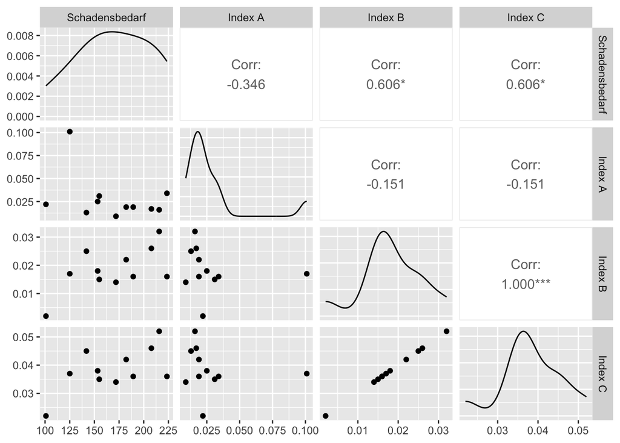

```r
library(fpp3)

d_raw |>
  rename(
    Schadensbedarf = `Historischer Schadenbedarf`
    , `Index A` = `Jährliche Inflation Index A`
    , `Index B` = `Jährliche Inflation Index B`
    , `Index C` = `Jährliche Inflation Index C`
  ) |>
  GGally::ggpairs(2:5)
```

- Indizes B und C sind perfekt kolinear
- Paarweise Vergleiche zeigen hohe bivariate Korrelationen von Index B/C mit den jährlichen Schadensbedarfen
- Index A korreliert negativ mit den Schadensbedarfen
- Zur Abschätzung der marginalen Effekte wird eine einfache Multivariate Regression für Zeitreihen gerechnet (Einschränkungen durch geringe Stichprobengröße bei Interpretation berücksichtigen)
- Schadensbedarfe haben scheinbar einen leichten positiven Trend, daher wird auch ein Modell mit einem `trend()` getestet

```r
fit_schaden <- d_raw |>
  tsibble(index = Anfalljahr) |>
  model(
    TSLM_AB = TSLM(`Historischer Schadenbedarf` ~  `Jährliche Inflation Index A` + `Jährliche Inflation Index B`)
    , TSLM_AB_Trend = TSLM(`Historischer Schadenbedarf` ~ trend() + `Jährliche Inflation Index A` + `Jährliche Inflation Index B`)
    , TSLM_B_Trend = TSLM(`Historischer Schadenbedarf` ~ trend() + `Jährliche Inflation Index B`)
    , TSLM_B = TSLM(`Historischer Schadenbedarf` ~ `Jährliche Inflation Index B`)
    )

glance(fit_schaden) |>
  transmute(Model = .model, adj_r_squared, CV, AIC, AICc, BIC) |>
  knitr::kable()
```

| Model | adj_r_squared | CV | AIC | AICc | BIC |
| --- | --- | --- | --- | --- | --- |
| TSLM_AB | 0.2928033 | 3656.398 | 81.12025 | 87.78692 | 82.71183 |
| TSLM_AB_Trend | 0.4242795 | 3119.866 | 79.38886 | 91.38886 | 81.37833 |
| TSLM_B_Trend | 0.3764999 | 1103.674 | 79.73469 | 86.40136 | 81.32628 |
| TSLM_B | 0.2975563 | 1225.040 | 80.34169 | 83.77026 | 81.53537 |

```r
fit_schaden_final <- d_raw |>
  tsibble(index = Anfalljahr) |>
  model(
    tslm = TSLM(`Historischer Schadenbedarf` ~ `Jährliche Inflation Index B`)
    )
report(fit_schaden_final)
```

```
Series: Historischer Schadenbedarf
Model: TSLM

Residuals:
    Min      1Q  Median      3Q     Max
-47.393 -17.216   1.905  15.488  61.180

Coefficients:
                              Estimate Std. Error t value Pr(>|t|)
(Intercept)                     114.33      26.09   4.382  0.00177 **
`Jährliche Inflation Index B`  2999.13    1310.68   2.288  0.04791 *
---
Signif. codes:  0 '***' 0.001 '**' 0.01 '*' 0.05 '.' 0.1 ' ' 1

Residual standard error: 32.44 on 9 degrees of freedom
Multiple R-squared: 0.3678, Adjusted R-squared: 0.2976
F-statistic: 5.236 on 1 and 9 DF, p-value: 0.047913
```

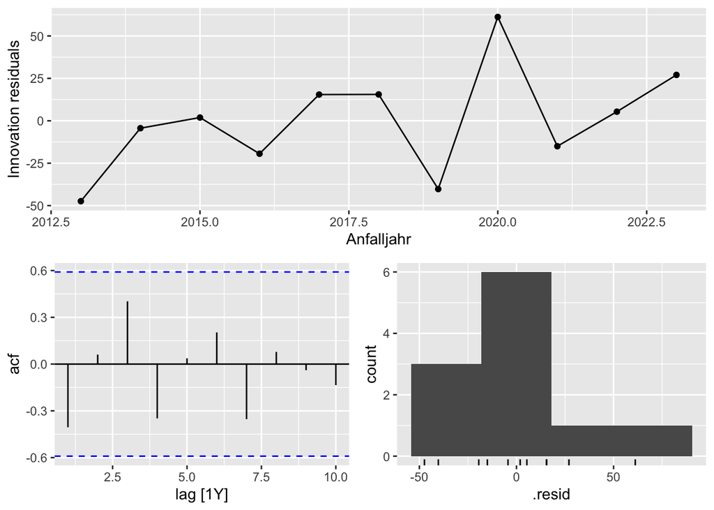

```r
gg_tsresiduals(fit_schaden_final)
```

- Gesamtheitliche Betrachtung der Informationskriterien zeigt, dass ein Modell nur mit Index B zu bevorzugen ist, auch wenn R<sup>2</sup> dadurch nicht maximiert wird
- Ein Trend verbessert die Varianzaufklärung, ist jedoch insbesondere unter Berücksichtigung des AICc keine bedeutende Ergänzung für das Modell
- Vergleiche der Modelle zeigen damit auch keinen zusätzlichen Informationszugewinn durch das Einbeziehen von Index A

> **Index B bildet insgesamt zwar nicht den gesamten Effekt in der Entwicklung der Schadensbedarfe ab, jedoch wäre er basierend auf den verfügbaren Informationen ein vielversprechender Prädiktor.**

TODO: haben wir in Zeitreihe A einen Outlier und wie würde dies die Ergebnisse verändern?

# Renten

## Fragestellungen

- Welche zusätzliche Information lassen sich aus den vorhandenen Daten ableiten?
- Welche Auffälligkeiten oder Zusammenhänge lassen sich im Datensatz finden?